# 6 Analyze your data

After completing this set of activities, you should be able to:

- modify a scatterplot using `ggplot2` in the `Rstudio Cloud IDE` to depict the relationship between two variables.
- modify a bar plot using `ggplot2` in the `Rstudio Cloud IDE` to compare differences in values.
- modify a heatplot using `ggplot2` in the `Rstudio Cloud IDE` to visualize categorical data
- print a table in the console using `kable()`.

You will also be familiarized with some of the data wrangling verbs (`filter()`, `select()`, `mutate()`, `group_by()`, `summarize()`, `arrange()`).

## 6.1 Sugar content (Benedict’s test)

You observed the color change for each milk type and documented the color before and after photographically. We would consider those images themselves as **data** because they are the raw observations we collected, they are the direct unprocessed evidence of our test results.

Any summary, categorization, or conclusions drawn from them would be **results**. In this case we will interpret our data based on a color chart and classify the color changes as levels of sugar content. These **interpreted findings** would be considered **results**.

In the shared google folder for your section, open the slidedeck with our benedict’s test photos in the `data` folder. Additionally, you will find a spreadsheet in the `results` folder names `sugar`.

**Give it a try**

Together with your partner analyze the photos from the sugar tests.

- create a copy of the spreadsheet and rename it `sugar_initials-initials` (include initials of both you and your lab partner.
- view the before/after images of the Benedicts test and for each milk type and age determine the sugar content as
  - none (blue)
  - traceable (green)
  - low (yellow)
  - moderate (dark orange)
  - high (brick red)

.

**Consider this**

As part of your discussion section you will discuss constraints/limitations of the experiment, inconsistencies in your results, and other possible explanations.

Together with your partner discuss whether these findings correspond to what you expected to see, if not, discuss whether this is an issue with the experimental design (methods) or an actual contradiction to your expectations.

.

**Answer**

**Expectation vs. Observed Results**

We expected different initial amounts of reducing sugars in whole milk, chocolate milk, buttermilk, and oat milk due to their varying compositions. Additionally, we anticipated a decrease in sugar concentration over time as microbes metabolized available carbohydrates. However, our Benedict’s test results consistently indicated moderate amounts of reducing sugars (orange color) across all samples and time points.

This finding contrasts with our expectation that microbial fermentation would gradually deplete sugars, particularly in dairy milk where lactose is converted into lactic acid. The persistence of reducing sugars suggests either an issue with our experimental design or an alternative explanation for the observed results.

**Experimental Constraints and Limitations**

*Think about which of these you think is the most realistic explanation for our experiment.*

1. **Sensitivity of the Benedict’s Test**
   - The Benedict’s test detects reducing sugars but does not differentiate between types or quantify exact concentrations.
   - The test may not be sensitive enough to detect gradual reductions in sugar concentration.
2. **Interference from Milk Components**
   - Some milk proteins and lipids could interfere with Benedict’s reagent, potentially masking subtle changes in sugar content.
   - Chocolate milk contains added sugars (e.g., sucrose, which can hydrolyze into glucose and fructose) that may sustain the presence of reducing sugars even as microbial metabolism progresses.
3. **Microbial Metabolism Pathways**
   - While we expected microbial fermentation to deplete reducing sugars, some microbes can also break down complex carbohydrates into simpler sugars.
   - For instance, oat milk contains starch-derived sugars, and microbial enzymatic activity might have continued breaking down starches into reducing sugars, counteracting expected sugar loss.
4. **Variability in Microbial Growth Rates**
   - The rate of microbial succession and sugar metabolism might have been slower than anticipated, meaning that significant sugar consumption had not yet occurred by the time we tested.
   - If different microbial populations dominated at different time points, some may have consumed sugars rapidly while others may not have metabolized them as efficiently.
5. **Experimental Timing**
   - The Benedict’s test was performed at discrete time points, and we may have missed key phases where sugar concentrations fluctuated more dramatically.

**Reflection and Future Considerations**

- To better assess sugar metabolism, we could use a **quantitative assay**, such as a glucose-specific test strip or a spectrophotometric assay, to track sugar concentration more accurately.
- Measuring additional parameters, such as **lactic acid concentration** or **CO₂ production**, could provide a clearer picture of microbial metabolic activity.
- Extending the experimental duration or sampling more frequently might reveal more pronounced trends in sugar consumption.

.

**Your Answer Here**

[Take some notes]

## 6.2 pH

We measured the pH for each milk treatment. Two groups determined the pH value so across all groups and sections we have four measurements.

These are what we would consider **technical replicates** which are repeated measurements or observations made on the same sample or experimental unit. These replicates are used to assess the precision and consistency of the measurement process. For instance, if you’re measuring the concentration of a substance in a solution as we did with the pH, you might perform the same measurement multiple times (e.g., by pipetting from the same sample) to account for any variability in the technique or equipment used. Technical replicates ensure that the measurement process is reliable and that any observed differences are due to true biological variation, not errors in measurement[^1].

<sup>1</sup> By constrast, a **biological replicate** refers to independent samples that come from different biological sources or experimental units. These replicates are used to account for natural variability within a biological system. For example, if you’re studying the effect of a treatment on plant growth, biological replicates would involve treating different plants, each representing an independent individual or biological unit. These replicates help ensure that the observed effects are generalizable and not due to individual differences between a single organism or sample. In our case, each beaker was poured separately from the same container so we are actually not even measuring a time series from the pH from the same spoilage event, they are all completely independent and especially Section A measured the same container twice.

**Consider this**

Discuss with your partner how we can analyze our pH data set. Include what type of summary figures or tables would be helpful to present your data to other people.

.

**Answer**

If we had biological replicates we would want to generate descriptive statistics like the mean and standard deviation for each milk treatment (type and time point) to get a sense of the central tendency and variation across spoilage events. The minimum and maximum values would give us the range of pH values. All of these numbers could be organized in a table.

We would also want to determine trends and changes over time.

- **Plot pH over time** for each milk treatment to observe trends in pH changes (e.g., line graphs showing pH on the y-axis and milk age on the x-axis for each milk type). We would want to create **separate lines for each milk type** to allow for easy comparison of trends over the 8 days.
- **Create boxplots** for pH values at each time point (0, 1, 4, 8 days) for each milk type. Boxplots can help visualize the spread and central tendency, as well as highlight any outliers or anomalies - we cannot doe this with our data set because we do not have biological replicates.
- **Compare the rate of change in pH** among milk treatments (e.g., whether some milks acidify more quickly than others).
- **Determine the absolut change in pH after 8 days** compared to the unspoiled control (refrigerated milk).

.

**Your Answer Here**

[Take some notes]

Let’s start by creating a summary figure showing the change in pH over time for each milk type. To do this we first need to read in our data set.

```r
library(readr)
library(janitor)
library(here)
library(dplyr)
library(tidyr)
library(knitr)
library(ggplot2)


# read in data set
ph <- read_delim(here("data", "tidy_ph.csv"),  # specify folder, file
                 delim = ",")


# take a look at first few rows
head(ph)
```

```
# A tibble: 6 × 4
  milk_type   age measurement    ph
  <chr>     <dbl> <chr>       <dbl>
1 whole         0 pH1          6.6
2 whole         0 pH2          6.51
3 whole         0 pH3          6.6
4 whole         0 pH4          6.68
5 whole         1 pH1          6.84
6 whole         1 pH2          6.76
```

You will notice that this is what we call a long or tidy format:

1. Each variable is a column; each column is a variable.
2. Each observation is a row; each row is an observation.
3. Each value is a cell; each cell is a single value.

This isn’t the most helpful format for humans to compare data, but it will allow us to efficiently create a new `dataframe` of our mean values across all measurements. First, we will group our data by milk type and age, and then calculate the mean for each treatment.

```r
mean_ph <- ph |>
  group_by(milk_type, age) |>
  summarize(mean_ph = mean(ph, na.rm = TRUE))
```

### 6.2.1 Summary table mean pH

If we wanted to create a handy summary table for a report we could convert it into a wide format and print it:

```r
mean_ph |>
  pivot_wider(names_from = milk_type, values_from = mean_ph) |>
  kable(digits = 2)
```

| age | buttermilk | chocolate | oat | whole |
| --- | --- | --- | --- | --- |
| 0 | 4.36 | 6.37 | 7.48 | 6.60 |
| 1 | 4.35 | 6.44 | 7.72 | 6.76 |
| 4 | 4.33 | 5.92 | 7.49 | 4.46 |
| 8 | 4.31 | 4.82 | 6.92 | 4.61 |

**Give it a try**

Try modifying the code above to create a summary table with milk type in the first column and the ages in the next four columns.

**Answer**

```r
mean_ph |>
  pivot_wider(names_from = age, values_from = mean_ph) |>
  kable(digits = 2)
```

| milk_type | 0 | 1 | 4 | 8 |
| --- | --- | --- | --- | --- |
| buttermilk | 4.36 | 4.35 | 4.33 | 4.31 |
| chocolate | 6.37 | 6.44 | 5.92 | 4.82 |
| oat | 7.48 | 7.72 | 7.49 | 6.92 |
| whole | 6.60 | 6.76 | 4.46 | 4.61 |

### 6.2.2 Scatterplot pH over time

These tables are helpful because they give us the actual numbers but visualization are generally a better way to identify key trends and make comparisons.

**Give it a try**

We are going to run the code for plotting line by line to see what each line does. When you are working in `R` you can always use a `#` to create a comment - `R` ignores everything after.

Annotate the code below to indicate how you are specifying which object to use, what column to plot on the x-axis, what column to plot on the y-axis, that we want a scatterplot, how we are indicating to color code according to milkt type and anything else you find informative.

You can also add comments to your script.

Let’s create a plot that shows the change in pH over time for each milk type.

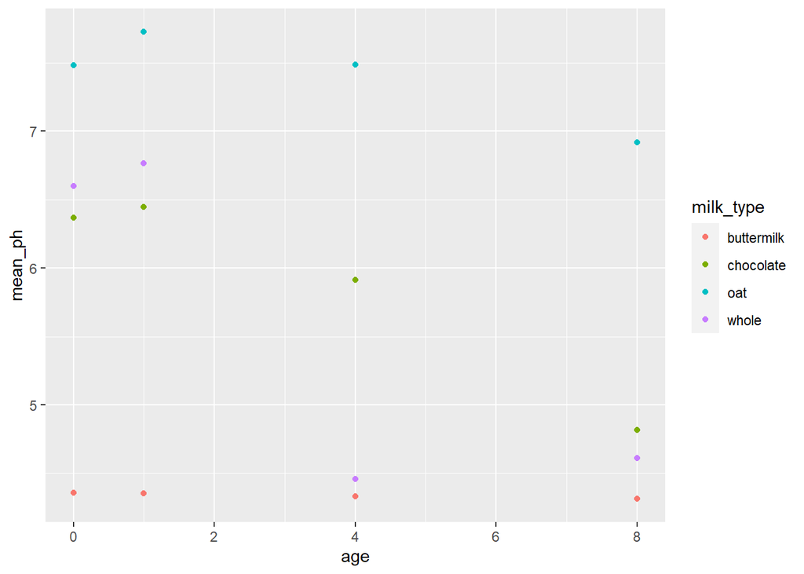

```r
ggplot(mean_ph,
       aes(x = age, y = mean_ph,
           color = milk_type)) +
  geom_point()
```

We can improve our plot, by changing the size of the data points, by choosing our own color scale, moving the legend, and by picking a theme.

**Give it a try**

Modify the code below:

1. `ggplot` will automatically use the column names as axis titles, pick better ones!
2. Pick an appropriate size for the data points so they are easily distinguishable.
3. Pick a color scale (you need four, they will be used alphabetical).
4. Try different locations for the legend “top”, “bottom”, “right”, “left”.
5. Pick a theme that enhances the readability of your plot.
   - theme_grey()
   - theme_bw()
   - theme_linedraw()
   - theme_light()
   - theme_minimal()
   - theme_classic()
   - theme_void()

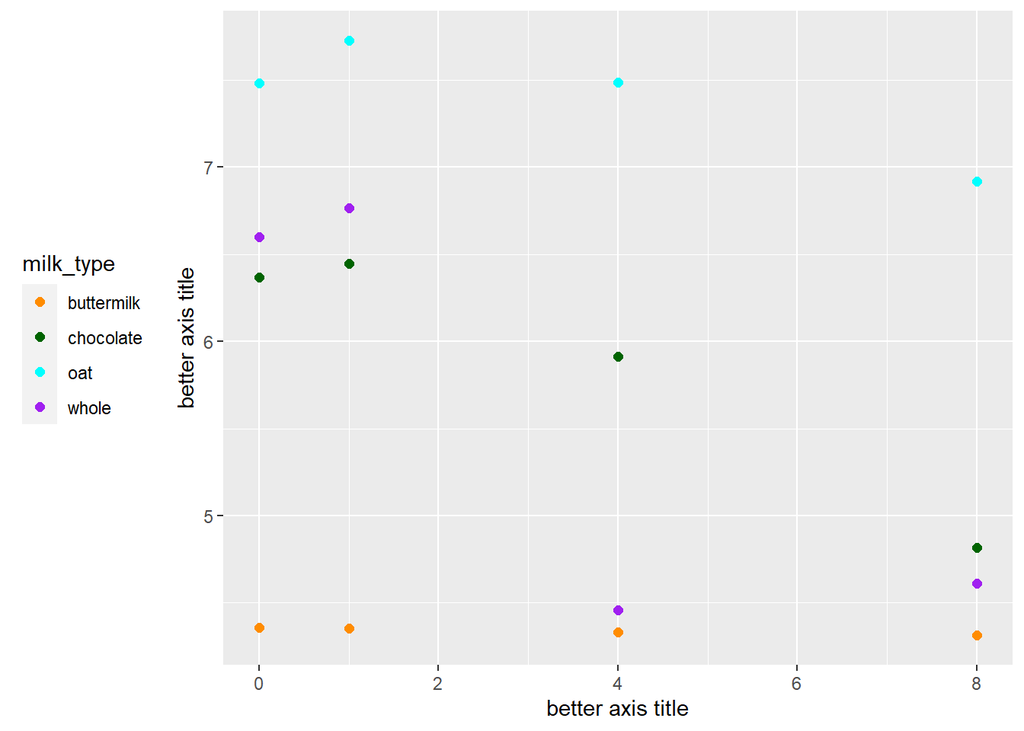

```r
# pick your colors
col <- c("darkorange", "darkgreen", "cyan", "purple")

# pick your point size
pt_size <- 2

ggplot(mean_ph,
       aes(x = age, y = mean_ph,
           color = milk_type)) +
  geom_point(size = pt_size) +
  scale_color_manual(values = col) +
  labs(x = "better axis title",
       y = "better axis title") +
  theme_grey() +
  theme(legend.position = "left")
```

With just the individual points it can be difficult to see trends, fortunately we can just add an additional layer to the plot useing `geom_line()` to add a line.